# Verbal fluency

# 1 Description of DataSchema variable

The description of harmonised variable is the following:

- Short name: `cog_verb`
- Variable label: `Cognition - verbal fluency`
- Variable description: `Test that assesses verbal (semantic) fluency: name as many animals as they could think of in 1 minute. Variable dichotomised by first quartil with value 0 and higher with value 1.`
- Domain: `Health status and functional limitations`
- Value type: `categorical`
- Category coding:

| **Code** | **Category Label** |
| --- | --- |
| 0 | <=25% |
| 1 | >25% |

- Category missings:

| **Code** | **Category Label** |
| --- | --- |
| 991 | CAPI/interviewer error |
| 992 | Impute |
| 993 | Disable to measure |
| 994 | Not attempt/not done |
| 995 | Does not answer |
| 996 | Not applicable |
| 997 | Refuse |
| 998 | Do not know |
| 999 | Missing |

- Short name: `cog_verb_c`
- Variable label: `Cognition - verbal fluency. Continuous variable`
- Variable description: `Test that assesses verbal (semantic) fluency: name as many animals as they could think of in 1 minute`
- Domain: `Health status and functional limitations`
- Value type: `continuous`
- Category missings:

| **Code** | **Category Label** |
| --- | --- |
| 991 | CAPI/interviewer error |
| 992 | Impute |
| 993 | Disable to measure |
| 994 | Not attempt/not done |
| 995 | Does not answer |
| 996 | Not applicable |
| 997 | Refuse |
| 998 | Do not know |
| 999 | Missing |

# 2 Data process

## 2.1 England

### 2.1.1 Wave 1

#### 2.1.1.1 Study-specific variable description

| **Name** | `cfani` |
| --- | --- |
| **Label** | `Number of animals mentioned after request to list as many as possible in one minute` |
| **Table name** | `wave_1_core_data_v3` |
| **Measure** | `Continuous Variable 0-50` |
| **Missings** | `-9 = Refusal` `-8 = Don't know` `-1 = Not applicable` |
| **Description** |  |

cfani

| Sample size | Missing values |
| --- | --- |
| 12099 | 386 |

Values

|  | No-missings | -8 | -9 | -1 | NA |
| --- | --- | --- | --- | --- | --- |
| Frequency | 11713.00 | 17.00 | 77.00 | 292.00 | 0 |
| Percentage | 96.81 | 0.14 | 0.64 | 2.41 | 0 |

Summary

| Min. | 1st Qu. | Median | Mean | 3rd Qu. | Max. |
| --- | --- | --- | --- | --- | --- |
| 0 | 15 | 19 | 19.33 | 23 | 50 |

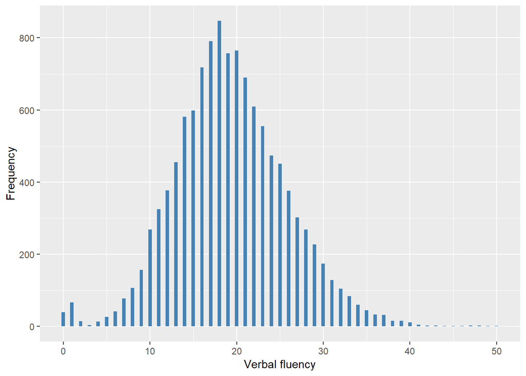

#### 2.1.1.2 Harmonisation algorithm

To compute the harmonize variable `cog_verb_c` from the study-specific variable the missing values have to be recoded as follows:

- `NA into 999`
- `-9 Refusal into 997`
- `-8 Don't know into 998`
- `-1 Not applicable into 996`

To compute the harmonized variable `cog_verb` from `cog_verb_c` it has to be recoded as follows:

- `cog_verb_c <=25% into 0`
- `cog_verb_c >25% into 1`

**R script:**

```r
# cog_verb_c
ELSA_ds_w1 <- tibble(id = ELSA_w1_cog_verb$id)
ELSA_ds_w1$cog_verb_c <- car::recode(ELSA_w1_cog_verb$cfani, "-9=997; -8=998; -1=996")
ELSA_ds_w1$cog_verb_c <- labelled(ELSA_ds_w1$cog_verb_c, labels = c(Missing = 999,
    `Do not know` = 998, Refuse = 997, `Not applicable` = 996, `Does not answer` = 995,
    `Not attempt not done` = 994, `Disable to measure` = 993, Impute = 992,
    `CAPI interviewer error` = 991))

# cog_verb
Q <- quantile(car::recode(ELSA_ds_w1$cog_verb_c, "999=NA; 997=NA; 998=NA; 996=NA"),
    probs = 1/4, na.rm = TRUE, names = FALSE)

ELSA_ds_w1$cog_verb <- car::recode(ELSA_ds_w1[[2]], "0:Q=0; (Q+1):900=1")
ELSA_ds_w1$cog_verb <- labelled(ELSA_ds_w1[[3]], labels = c(`<=25%` = 0, `>25%` = 1,
    Missing = 999, `Do not know` = 998, Refuse = 997, `Not applicable` = 996,
    `Does not answer` = 995, `Not attempt not done` = 994, `Disable to measure` = 993,
    Impute = 992, `CAPI interviewer error` = 991))
```

#### 2.1.1.3 Statistical description of the new harmonised variable

Cognition - verbal fluency. Test that assesses verbal (semantic) fluency: name as many animals as they could think of in 1 minute

| Sample size | Missing values |
| --- | --- |
| 12099 | 386 |

Values

|  | No-missings | 991 | 992 | 993 | 994 | 995 | 996 | 997 | 998 | 999 | NA |
| --- | --- | --- | --- | --- | --- | --- | --- | --- | --- | --- | --- |
| Frequency | 11713.00 | 0 | 0 | 0 | 0 | 0 | 292.00 | 77.00 | 17.00 | 0 | 0 |
| Percentage | 96.81 | 0 | 0 | 0 | 0 | 0 | 2.41 | 0.64 | 0.14 | 0 | 0 |

Summary

| Min. | 1st Qu. | Median | Mean | 3rd Qu. | Max. |
| --- | --- | --- | --- | --- | --- |
| 0 | 15 | 19 | 19.33 | 23 | 50 |

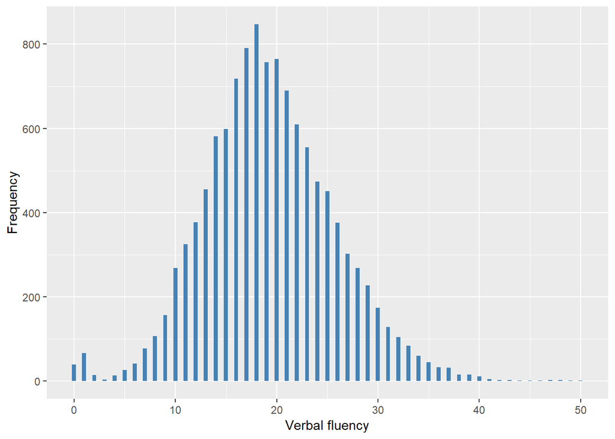

Cognition - verbal fluency. Test that assesses verbal (semantic) fluency: name as many animals as they could think of in 1 minute. Discrete variable: value 0 = <=25%; value 1 = >25%

| Sample size | Missing values |
| --- | --- |
| 12099 | 386 |

Category

|  | 0 | 1 |
| --- | --- | --- |
| Frequency | 3155.00 | 8558.00 |
| Percentage | 26.08 | 70.73 |

Type of missing

|  | 991 | 992 | 993 | 994 | 995 | 996 | 997 | 998 | 999 | NA |
| --- | --- | --- | --- | --- | --- | --- | --- | --- | --- | --- |
| Frequency | 0 | 0 | 0 | 0 | 0 | 292.00 | 77.00 | 17.00 | 0 | 0 |
| Percentage | 0 | 0 | 0 | 0 | 0 | 2.41 | 0.64 | 0.14 | 0 | 0 |

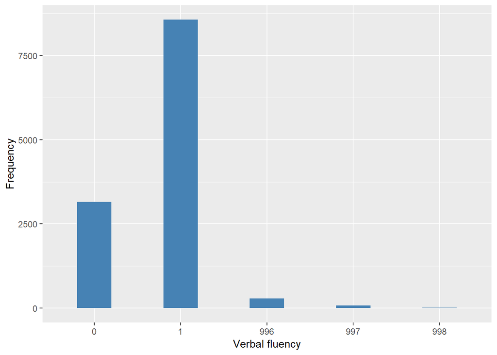

#### 2.1.1.4 Validation

Continuous vs Dichotomous

|  | 0:15->0 | 16:160->1 | -1->996 | -9->997 | -8->998 |
| --- | --- | --- | --- | --- | --- |
| continuous | 3155 | 8558 | 292 | 77 | 17 |
| dichotomous | 3155 | 8558 | 292 | 77 | 17 |

### 2.1.2 Wave 2

#### 2.1.2.1 Study-specific variable description

| **Name** | `CfAni` |
| --- | --- |
| **Label** | `Number of animals mentioned (fluency)` |
| **Table name** | `wave_2_core_data_v4` |
| **Measure** | `Continuous Variable 0-63` |
| **Missings** | `-9 = Refusal` `-8 = Don't know` `-1 = Not applicable` |
| **Description** |  |

CfAni

| Sample size | Missing values |
| --- | --- |
| 9432 | 180 |

Values

|  | No-missings | -8 | -9 | -1 | NA |
| --- | --- | --- | --- | --- | --- |
| Frequency | 9252.00 | 14.00 | 14.00 | 152.00 | 0 |
| Percentage | 98.09 | 0.15 | 0.15 | 1.61 | 0 |

Summary

| Min. | 1st Qu. | Median | Mean | 3rd Qu. | Max. |
| --- | --- | --- | --- | --- | --- |
| 0 | 15 | 20 | 19.81 | 24 | 63 |

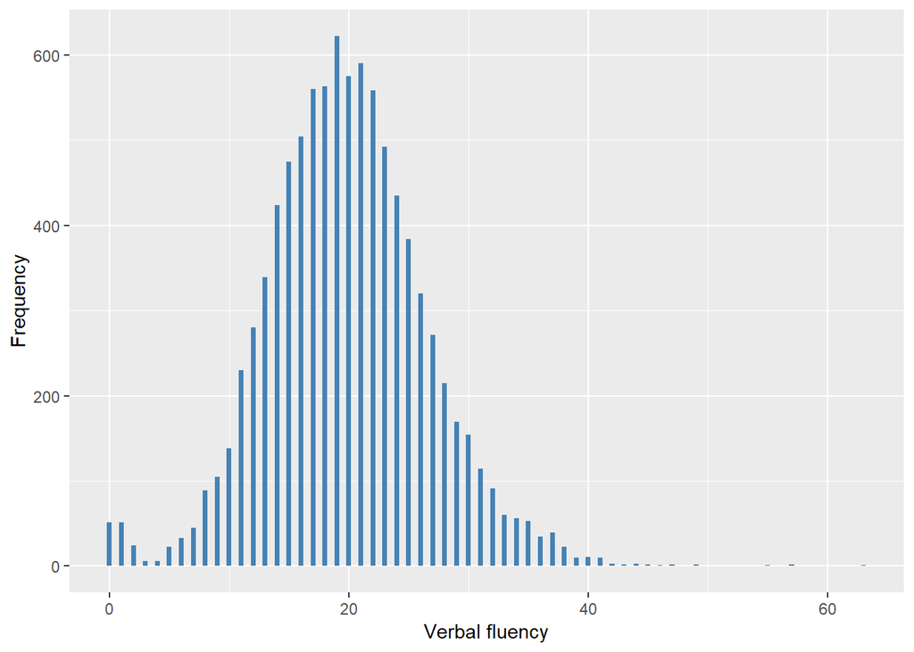

#### 2.1.2.2 Harmonisation algorithm

To compute the harmonize variable `cog_verb_c` from the study-specific variable the missing values have to be recoded as follows:

- `NA into 999`
- `-9 Refusal into 997`
- `-8 Don't know into 998`
- `-1 Not applicable into 996`

To compute the harmonized variable `cog_verb` from `cog_verb_c` it has to be recoded as follows:

- `cog_verb_c <=25% into 0`
- `cog_verb_c >25% into 1`

**R script:**

```r
# cog_verb_c
ELSA_ds_w2 <- tibble(id = ELSA_w2_cog_verb$id)
ELSA_ds_w2$cog_verb_c <- car::recode(ELSA_w2_cog_verb$CfAni, "-9=997; -8=998; -1=996")
ELSA_ds_w2$cog_verb_c <- labelled(ELSA_ds_w2$cog_verb_c, labels = c(Missing = 999,
    `Do not know` = 998, Refuse = 997, `Not applicable` = 996, `Does not answer` = 995,
    `Not attempt not done` = 994, `Disable to measure` = 993, Impute = 992,
    `CAPI interviewer error` = 991))

# cog_verb
Q <- quantile(car::recode(ELSA_ds_w2$cog_verb_c, "999=NA; 997=NA; 998=NA; 996=NA"),
    probs = 1/4, na.rm = TRUE, names = FALSE)

ELSA_ds_w2$cog_verb <- car::recode(ELSA_ds_w2[[2]], "0:Q=0; (Q+1):900=1")
ELSA_ds_w2$cog_verb <- labelled(ELSA_ds_w2[[3]], labels = c(`<=25%` = 0, `>25%` = 1,
    Missing = 999, `Do not know` = 998, Refuse = 997, `Not applicable` = 996,
    `Does not answer` = 995, `Not attempt not done` = 994, `Disable to measure` = 993,
    Impute = 992, `CAPI interviewer error` = 991))
```

#### 2.1.2.3 Statistical description of the new harmonised variable

Cognition - verbal fluency. Test that assesses verbal (semantic) fluency: name as many animals as they could think of in 1 minute

| Sample size | Missing values |
| --- | --- |
| 9432 | 180 |

Values

|  | No-missings | 991 | 992 | 993 | 994 | 995 | 996 | 997 | 998 | 999 | NA |
| --- | --- | --- | --- | --- | --- | --- | --- | --- | --- | --- | --- |
| Frequency | 9252.00 | 0 | 0 | 0 | 0 | 0 | 152.00 | 14.00 | 14.00 | 0 | 0 |
| Percentage | 98.09 | 0 | 0 | 0 | 0 | 0 | 1.61 | 0.15 | 0.15 | 0 | 0 |

Summary

| Min. | 1st Qu. | Median | Mean | 3rd Qu. | Max. |
| --- | --- | --- | --- | --- | --- |
| 0 | 15 | 20 | 19.81 | 24 | 63 |

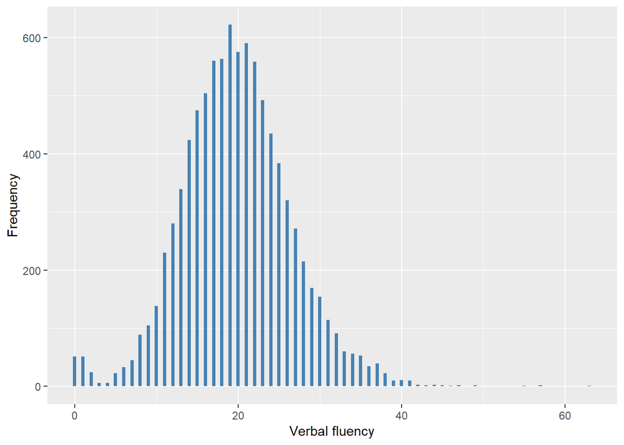

Cognition - verbal fluency. Test that assesses verbal (semantic) fluency: name as many animals as they could think of in 1 minute. Discrete variable: value 0 = <=25%; value 1 = >25%

| Sample size | Missing values |
| --- | --- |
| 9432 | 180 |

Category

|  | 0 | 1 |
| --- | --- | --- |
| Frequency | 2319.00 | 6933.00 |
| Percentage | 24.59 | 73.51 |

Type of missing

|  | 991 | 992 | 993 | 994 | 995 | 996 | 997 | 998 | 999 | NA |
| --- | --- | --- | --- | --- | --- | --- | --- | --- | --- | --- |
| Frequency | 0 | 0 | 0 | 0 | 0 | 152.00 | 14.00 | 14.00 | 0 | 0 |
| Percentage | 0 | 0 | 0 | 0 | 0 | 1.61 | 0.15 | 0.15 | 0 | 0 |

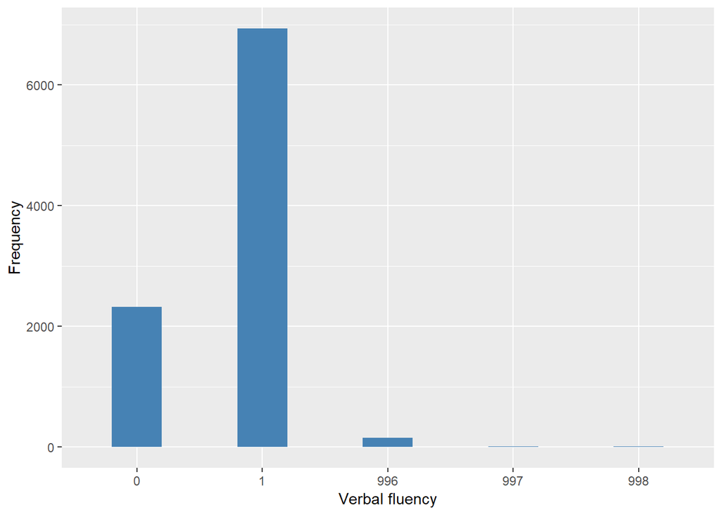

#### 2.1.2.4 Validation

Continuous vs Dichotomous

|  | 0:15->0 | 16:160->1 | -1->996 | -9->997 | -8->998 |
| --- | --- | --- | --- | --- | --- |
| continuous | 2319 | 6933 | 152 | 14 | 14 |
| dichotomous | 2319 | 6933 | 152 | 14 | 14 |

### 2.1.3 Wave 3

#### 2.1.3.1 Study-specific variable description

| **Name** | `cfani` |
| --- | --- |
| **Label** | `Number of animals mentioned (fluency)` |
| **Table name** | `wave_3_elsa_data_v4` |
| **Measure** | `Continuous Variable 0-56` |
| **Missings** | `-9 = Refusal` `-8 = Don't know` `-1 = Not applicable` |
| **Description** |  |

Verbal fluency

| Sample size | Missing values |
| --- | --- |
| 9771 | 291 |

Values

|  | No-missings | -8 | -9 | -1 | NA |
| --- | --- | --- | --- | --- | --- |
| Frequency | 9480.00 | 0 | 21.00 | 270.00 | 0 |
| Percentage | 97.02 | 0 | 0.21 | 2.76 | 0 |

Summary

| Min. | 1st Qu. | Median | Mean | 3rd Qu. | Max. |
| --- | --- | --- | --- | --- | --- |
| 0 | 16 | 20 | 20.24 | 25 | 56 |

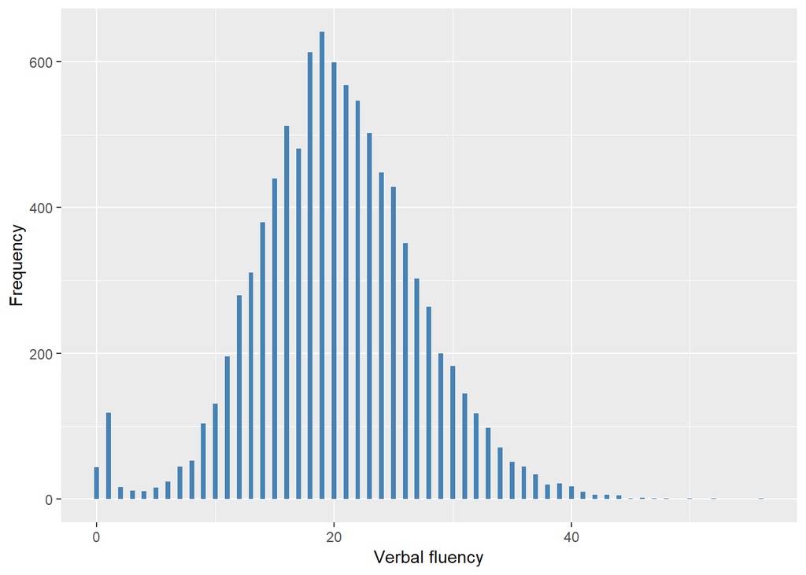

#### 2.1.3.2 Harmonisation algorithm

To compute the harmonize variable `cog_verb_c` from the study-specific variable the missing values have to be recoded as follows:

- `NA into 999`
- `-9 Refusal into 997`
- `-8 Don't know into 998`
- `-1 Not applicable into 996`

To compute the harmonized variable `cog_verb` from `cog_verb_c` it has to be recoded as follows:

- `cog_verb_c <=25% into 0`
- `cog_verb_c >25% into 1`

**R script:**

```r
# cog_verb_c
ELSA_ds_w3 <- tibble(id = ELSA_w3_cog_verb$id)
ELSA_ds_w3$cog_verb_c <- car::recode(ELSA_w3_cog_verb$cfani, "-9=997; -8=998; -1=996")
ELSA_ds_w3$cog_verb_c <- labelled(ELSA_ds_w3$cog_verb_c, labels = c(Missing = 999,
    `Do not know` = 998, Refuse = 997, `Not applicable` = 996, `Does not answer` = 995,
    `Not attempt not done` = 994, `Disable to measure` = 993, Impute = 992,
    `CAPI interviewer error` = 991))

# cog_verb
Q <- quantile(car::recode(ELSA_ds_w3$cog_verb_c, "999=NA; 997=NA; 998=NA; 996=NA"),
    probs = 1/4, na.rm = TRUE, names = FALSE)

ELSA_ds_w3$cog_verb <- car::recode(ELSA_ds_w3[[2]], "0:Q=0; (Q+1):900=1")
ELSA_ds_w3$cog_verb <- labelled(ELSA_ds_w3[[3]], labels = c(`<=25%` = 0, `>25%` = 1,
    Missing = 999, `Do not know` = 998, Refuse = 997, `Not applicable` = 996,
    `Does not answer` = 995, `Not attempt not done` = 994, `Disable to measure` = 993,
    Impute = 992, `CAPI interviewer error` = 991))
```

#### 2.1.3.3 Statistical description of the new harmonised variable

Cognition - verbal fluency. Test that assesses verbal (semantic) fluency: name as many animals as they could think of in 1 minute

| Sample size | Missing values |
| --- | --- |
| 9771 | 291 |

Values

|  | No-missings | 991 | 992 | 993 | 994 | 995 | 996 | 997 | 998 | 999 | NA |
| --- | --- | --- | --- | --- | --- | --- | --- | --- | --- | --- | --- |
| Frequency | 9480.00 | 0 | 0 | 0 | 0 | 0 | 270.00 | 21.00 | 0 | 0 | 0 |
| Percentage | 97.02 | 0 | 0 | 0 | 0 | 0 | 2.76 | 0.21 | 0 | 0 | 0 |

Summary

| Min. | 1st Qu. | Median | Mean | 3rd Qu. | Max. |
| --- | --- | --- | --- | --- | --- |
| 0 | 16 | 20 | 20.24 | 25 | 56 |

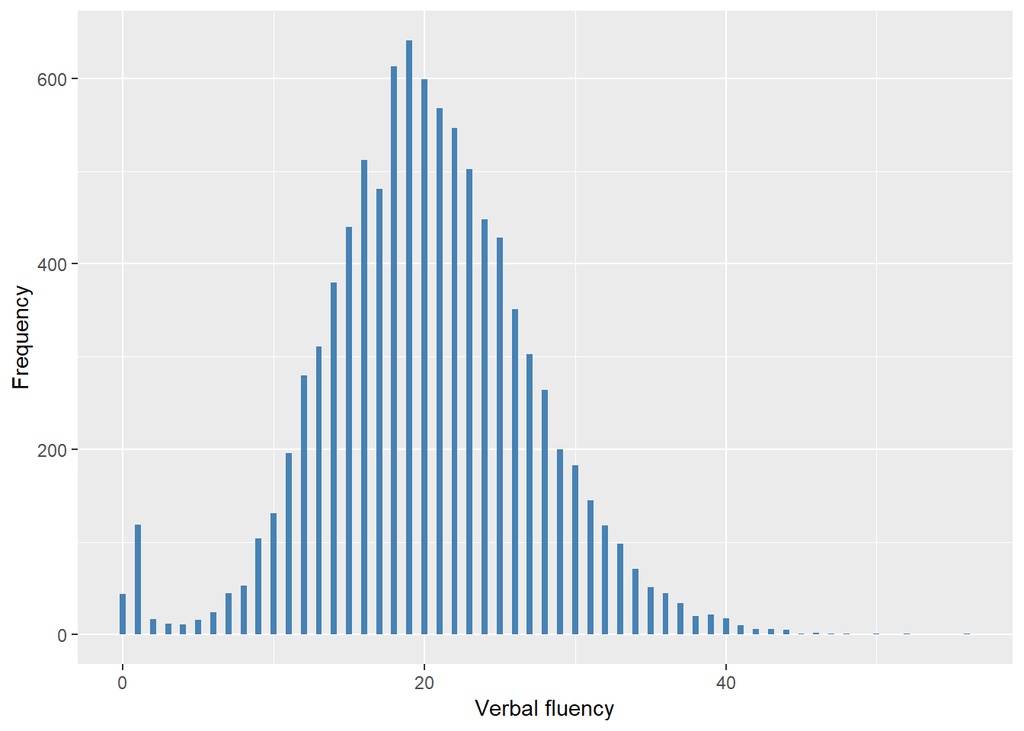

Cognition - verbal fluency. Test that assesses verbal (semantic) fluency: name as many animals as they could think of in 1 minute. Discrete variable: value 0 = <=25%; value 1 = >25%

| Sample size | Missing values |
| --- | --- |
| 9771 | 291 |

Category

|  | 0 | 1 |
| --- | --- | --- |
| Frequency | 2695.00 | 6785.00 |
| Percentage | 27.58 | 69.44 |

Type of missing

|  | 991 | 992 | 993 | 994 | 995 | 996 | 997 | 998 | 999 | NA |
| --- | --- | --- | --- | --- | --- | --- | --- | --- | --- | --- |
| Frequency | 0 | 0 | 0 | 0 | 0 | 270.00 | 21.00 | 0 | 0 | 0 |
| Percentage | 0 | 0 | 0 | 0 | 0 | 2.76 | 0.21 | 0 | 0 | 0 |

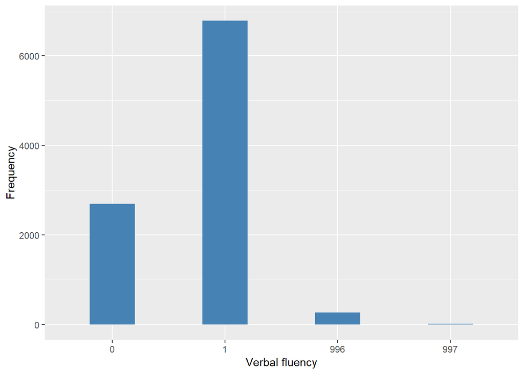

#### 2.1.3.4 Validation

Continuous vs Dichotomous

|  | 0:16->0 | 17:160->1 | -1->996 | -9->997 |
| --- | --- | --- | --- | --- |
| continuous | 2695 | 6785 | 270 | 21 |
| dichotomous | 2695 | 6785 | 270 | 21 |

### 2.1.4 Wave 4

#### 2.1.4.1 Study-specific variable description

| **Name** | `cfani` |
| --- | --- |
| **Label** | `Number of animals mentioned (fluency)` |
| **Table name** | `wave_4_elsa_data_v3` |
| **Measure** | `Continuous Variable 0-55` |
| **Missings** | `-9 = Refusal` `-8 = Don't know` `-1 = Not applicable` |
| **Description** |  |

Verbal fluency

| Sample size | Missing values |
| --- | --- |
| 11050 | 509 |

Values

|  | No-missings | -9 | -8 | -1 | NA |
| --- | --- | --- | --- | --- | --- |
| Frequency | 10541.00 | 59.00 | 4.00 | 446.00 | 0 |
| Percentage | 95.39 | 0.53 | 0.04 | 4.04 | 0 |

Summary

| Min. | 1st Qu. | Median | Mean | 3rd Qu. | Max. |
| --- | --- | --- | --- | --- | --- |
| 0 | 16 | 21 | 20.71 | 25 | 55 |

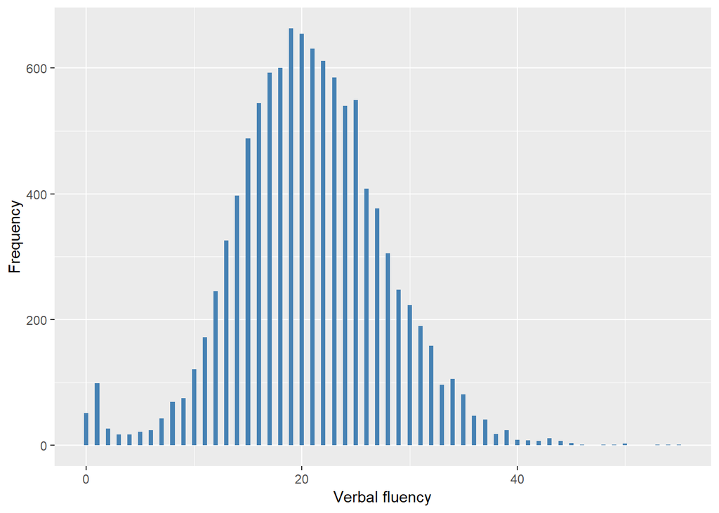

#### 2.1.4.2 Harmonisation algorithm

To compute the harmonize variable `cog_verb_c` from the study-specific variable the missing values have to be recoded as follows:

- `NA into 999`
- `-9 Refusal into 997`
- `-8 Don't know into 998`
- `-1 Not applicable into 996`

To compute the harmonized variable `cog_verb` from `cog_verb_c` it has to be recoded as follows:

- `cog_verb_c <=25% into 0`
- `cog_verb_c >25% into 1`

**R script:**

```r
# cog_verb_c
ELSA_ds_w4 <- tibble(id = ELSA_w4_cog_verb$id)
ELSA_ds_w4$cog_verb_c <- car::recode(ELSA_w4_cog_verb$cfani, "-9=997; -8=998; -1=996")
ELSA_ds_w4$cog_verb_c <- labelled(ELSA_ds_w4$cog_verb_c, labels = c(Missing = 999,
    `Do not know` = 998, Refuse = 997, `Not applicable` = 996, `Does not answer` = 995,
    `Not attempt not done` = 994, `Disable to measure` = 993, Impute = 992,
    `CAPI interviewer error` = 991))

# cog_verb
Q <- quantile(car::recode(ELSA_ds_w4$cog_verb_c, "999=NA; 997=NA; 998=NA; 996=NA"),
    probs = 1/4, na.rm = TRUE, names = FALSE)

ELSA_ds_w4$cog_verb <- car::recode(ELSA_ds_w4[[2]], "0:Q=0; (Q+1):900=1")
ELSA_ds_w4$cog_verb <- labelled(ELSA_ds_w4[[3]], labels = c(`<=25%` = 0, `>25%` = 1,
    Missing = 999, `Do not know` = 998, Refuse = 997, `Not applicable` = 996,
    `Does not answer` = 995, `Not attempt not done` = 994, `Disable to measure` = 993,
    Impute = 992, `CAPI interviewer error` = 991))
```

#### 2.1.4.3 Statistical description of the new harmonised variable

Cognition - verbal fluency. Test that assesses verbal (semantic) fluency: name as many animals as they could think of in 1 minute

| Sample size | Missing values |
| --- | --- |
| 11050 | 509 |

Values

|  | No-missings | 991 | 992 | 993 | 994 | 995 | 996 | 997 | 998 | 999 | NA |
| --- | --- | --- | --- | --- | --- | --- | --- | --- | --- | --- | --- |
| Frequency | 10541.00 | 0 | 0 | 0 | 0 | 0 | 446.00 | 59.00 | 4.00 | 0 | 0 |
| Percentage | 95.39 | 0 | 0 | 0 | 0 | 0 | 4.04 | 0.53 | 0.04 | 0 | 0 |

Summary

| Min. | 1st Qu. | Median | Mean | 3rd Qu. | Max. |
| --- | --- | --- | --- | --- | --- |
| 0 | 16 | 21 | 20.71 | 25 | 55 |

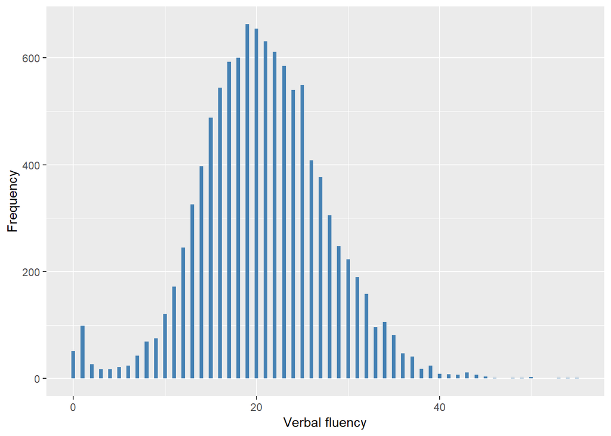

Cognition - verbal fluency. Test that assesses verbal (semantic) fluency: name as many animals as they could think of in 1 minute. Discrete variable: value 0 = <=25%; value 1 = >25%

| Sample size | Missing values |
| --- | --- |
| 11050 | 509 |

Category

|  | 0 | 1 |
| --- | --- | --- |
| Frequency | 2737.00 | 7804.00 |
| Percentage | 24.77 | 70.62 |

Type of missing

|  | 991 | 992 | 993 | 994 | 995 | 996 | 997 | 998 | 999 | NA |
| --- | --- | --- | --- | --- | --- | --- | --- | --- | --- | --- |
| Frequency | 0 | 0 | 0 | 0 | 0 | 446.00 | 59.00 | 4.00 | 0 | 0 |
| Percentage | 0 | 0 | 0 | 0 | 0 | 4.04 | 0.53 | 0.04 | 0 | 0 |

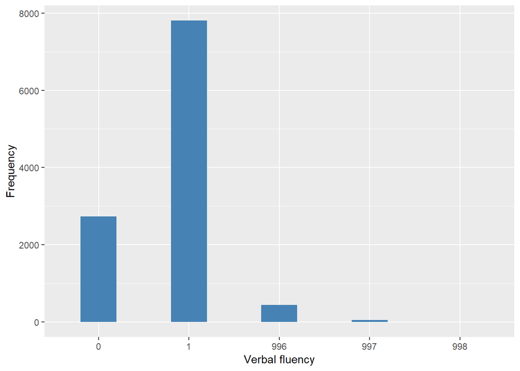

#### 2.1.4.4 Validation

Continuous vs Dichotomous

|  | 0:16->0 | 17:160->1 | -1->996 | -9->997 | -8->998 |
| --- | --- | --- | --- | --- | --- |
| continuous | 2737 | 7804 | 446 | 59 | 4 |
| dichotomous | 2737 | 7804 | 446 | 59 | 4 |

### 2.1.5 Wave 5

#### 2.1.5.1 Study-specific variable description

| **Name** | `cfani` |
| --- | --- |
| **Label** | `Number of animals mentioned (fluency)` |
| **Table name** | `wave_5_elsa_data_v4` |
| **Measure** | `Continuous Variable 0-51` |
| **Missings** | `-9 = Refusal` `-8 = Don't know` `-1 = Not applicable` |
| **Description** |  |

Verbal fluency

| Sample size | Missing values |
| --- | --- |
| 10274 | 612 |

Values

|  | No-missings | -8 | -9 | -1 | NA |
| --- | --- | --- | --- | --- | --- |
| Frequency | 9662.00 | 4.00 | 71.00 | 537.00 | 0 |
| Percentage | 94.04 | 0.04 | 0.69 | 5.23 | 0 |

Summary

| Min. | 1st Qu. | Median | Mean | 3rd Qu. | Max. |
| --- | --- | --- | --- | --- | --- |
| 0 | 16 | 21 | 20.79 | 25 | 51 |

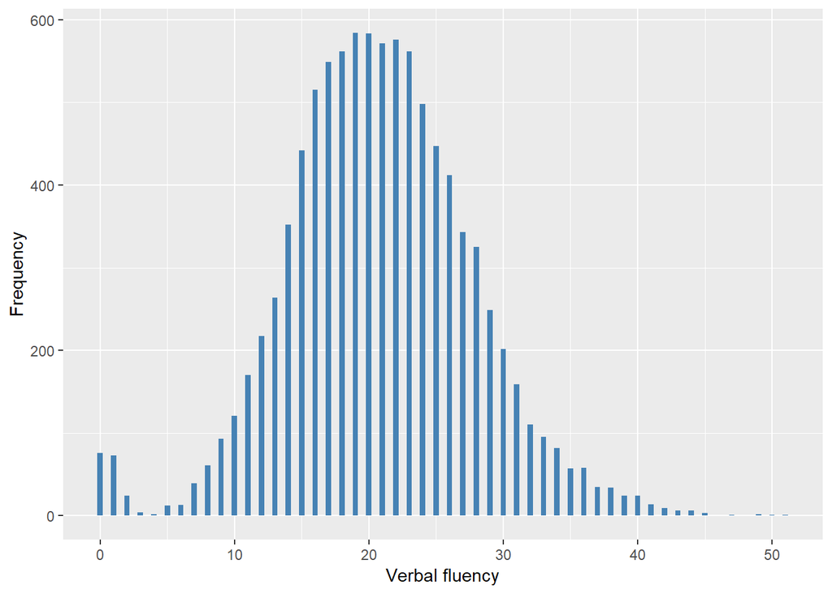

#### 2.1.5.2 Harmonisation algorithm

To compute the harmonize variable `cog_verb_c` from the study-specific variable the missing values have to be recoded as follows:

- `NA into 999`
- `-9 Refusal into 997`
- `-8 Don't know into 998`
- `-1 Not applicable into 996`

To compute the harmonized variable `cog_verb` from `cog_verb_c` it has to be recoded as follows:

- `cog_verb_c <=25% into 0`
- `cog_verb_c >25% into 1`

**R script:**

```r
# cog_verb_c
ELSA_ds_w5 <- tibble(id = ELSA_w5_cog_verb$id)
ELSA_ds_w5$cog_verb_c <- car::recode(ELSA_w5_cog_verb$cfani, "-9=997; -8=998; -1=996")
ELSA_ds_w5$cog_verb_c <- labelled(ELSA_ds_w5$cog_verb_c, labels = c(Missing = 999,
    `Do not know` = 998, Refuse = 997, `Not applicable` = 996, `Does not answer` = 995,
    `Not attempt not done` = 994, `Disable to measure` = 993, Impute = 992,
    `CAPI interviewer error` = 991))

# cog_verb
Q <- quantile(car::recode(ELSA_ds_w5$cog_verb_c, "999=NA; 997=NA; 998=NA; 996=NA"),
    probs = 1/4, na.rm = TRUE, names = FALSE)

ELSA_ds_w5$cog_verb <- car::recode(ELSA_ds_w5[[2]], "0:Q=0; (Q+1):900=1")
ELSA_ds_w5$cog_verb <- labelled(ELSA_ds_w5[[3]], labels = c(`<=25%` = 0, `>25%` = 1,
    Missing = 999, `Do not know` = 998, Refuse = 997, `Not applicable` = 996,
    `Does not answer` = 995, `Not attempt not done` = 994, `Disable to measure` = 993,
    Impute = 992, `CAPI interviewer error` = 991))
```

#### 2.1.5.3 Statistical description of the new harmonised variable

Cognition - verbal fluency. Test that assesses verbal (semantic) fluency: name as many animals as they could think of in 1 minute

| Sample size | Missing values |
| --- | --- |
| 10274 | 612 |

Values

|  | No-missings | 991 | 992 | 993 | 994 | 995 | 996 | 997 | 998 | 999 | NA |
| --- | --- | --- | --- | --- | --- | --- | --- | --- | --- | --- | --- |
| Frequency | 9662.00 | 0 | 0 | 0 | 0 | 0 | 537.00 | 71.00 | 4.00 | 0 | 0 |
| Percentage | 94.04 | 0 | 0 | 0 | 0 | 0 | 5.23 | 0.69 | 0.04 | 0 | 0 |

Summary

| Min. | 1st Qu. | Median | Mean | 3rd Qu. | Max. |
| --- | --- | --- | --- | --- | --- |
| 0 | 16 | 21 | 20.79 | 25 | 51 |

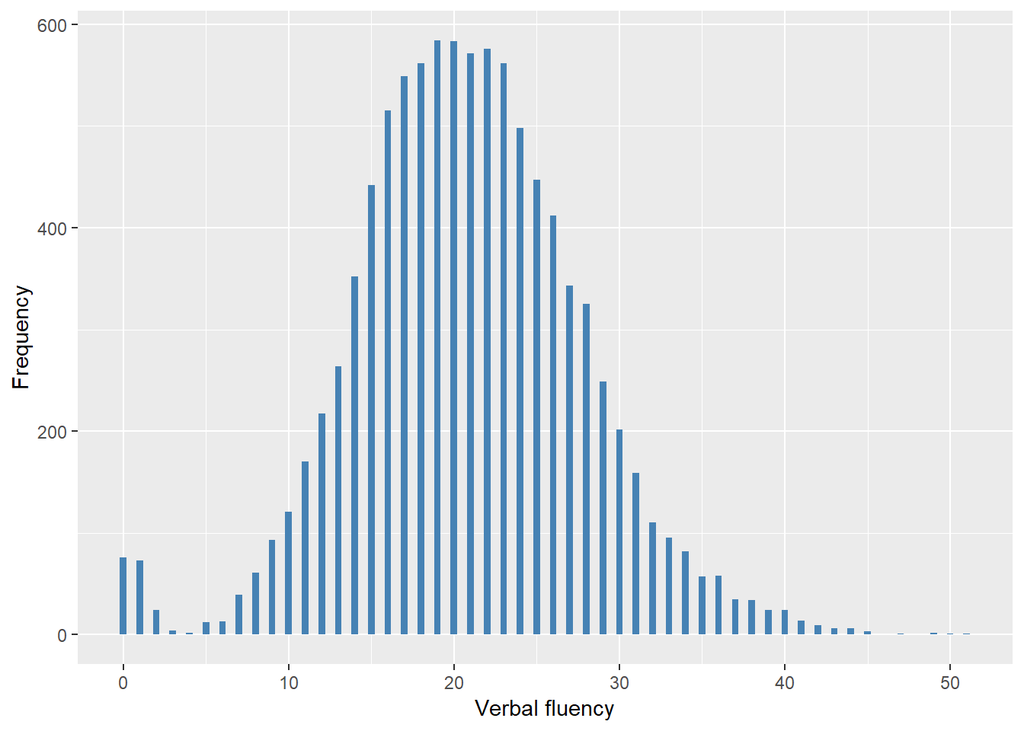

Cognition - verbal fluency. Test that assesses verbal (semantic) fluency: name as many animals as they could think of in 1 minute. Discrete variable: value 0 = <=25%; value 1 = >25%

| Sample size | Missing values |
| --- | --- |
| 10274 | 612 |

Category

|  | 0 | 1 |
| --- | --- | --- |
| Frequency | 2478.00 | 7184.00 |
| Percentage | 24.12 | 69.92 |

Type of missing

|  | 991 | 992 | 993 | 994 | 995 | 996 | 997 | 998 | 999 | NA |
| --- | --- | --- | --- | --- | --- | --- | --- | --- | --- | --- |
| Frequency | 0 | 0 | 0 | 0 | 0 | 537.00 | 71.00 | 4.00 | 0 | 0 |
| Percentage | 0 | 0 | 0 | 0 | 0 | 5.23 | 0.69 | 0.04 | 0 | 0 |

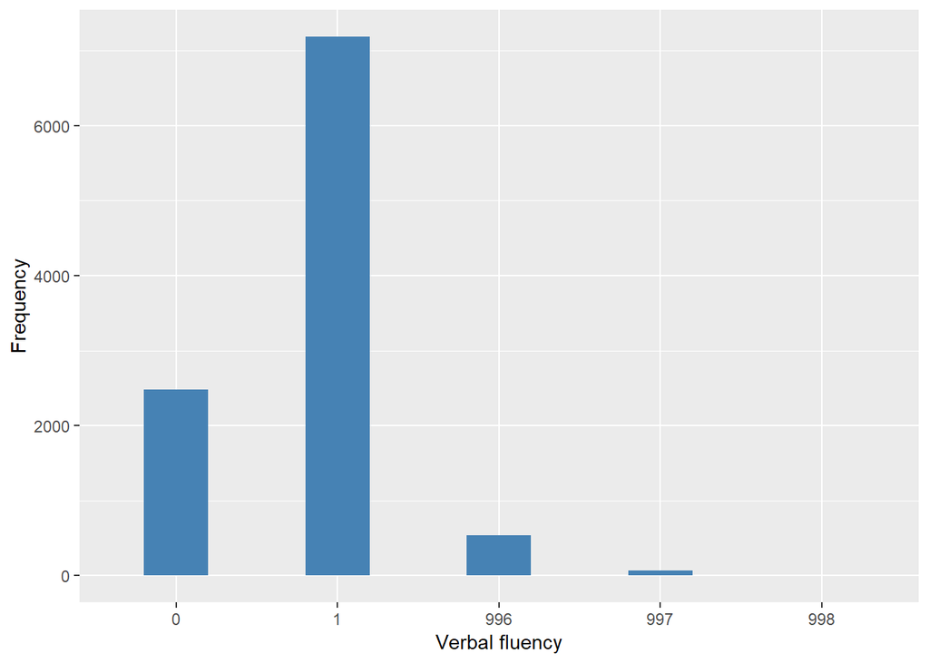

#### 2.1.5.4 Validation

Continuous vs Dichotomous

[output not shown]

### 2.1.6 Wave 6

Measure not found at wave 6.

### 2.1.7 Wave 7

#### 2.1.7.1 Study-specific variable description

| **Name** | `CfAni` |
| --- | --- |
| **Label** | `Number of animals mentioned (fluency)` |
| **Table name** | `wave_7_elsa_data` |
| **Measure** | `Continuous Variable 0-67` |
| **Missings** | `-9 = Refusal` `-8 = Don't know` `-1 = Not applicable` |
| **Description** |  |

Verbal fluency

| Sample size | Missing values |
| --- | --- |
| 9666 | 609 |

Values

|  | No-missings | -8 | -9 | -1 | NA |
| --- | --- | --- | --- | --- | --- |
| Frequency | 9057.0 | 0 | 12.00 | 597.00 | 0 |
| Percentage | 93.7 | 0 | 0.12 | 6.18 | 0 |

Summary

| Min. | 1st Qu. | Median | Mean | 3rd Qu. | Max. |
| --- | --- | --- | --- | --- | --- |
| 0 | 17 | 21 | 21.13 | 26 | 67 |

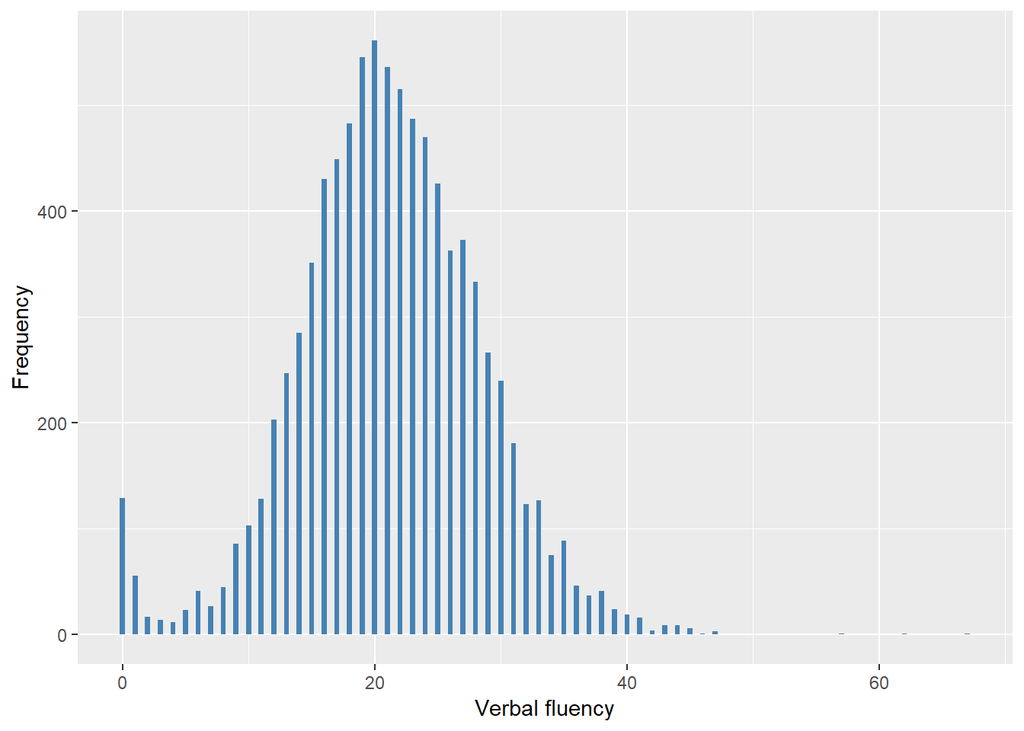

#### 2.1.7.2 Harmonisation algorithm

To compute the harmonize variable `cog_verb_c` from the study-specific variable the missing values have to be recoded as follows:

- `NA into 999`
- `-9 Refusal into 997`
- `-8 Don't know into 998`
- `-1 Not applicable into 996`

To compute the harmonized variable `cog_verb` from `cog_verb_c` it has to be recoded as follows:

- `cog_verb_c <=25% into 0`
- `cog_verb_c >25% into 1`

**R script:**

```r
# cog_verb_c
ELSA_ds_w7 <- tibble(id = ELSA_w7_cog_verb$id)
ELSA_ds_w7$cog_verb_c <- car::recode(ELSA_w7_cog_verb$CfAni, "-9=997; -8=998; -1=996")
ELSA_ds_w7$cog_verb_c <- labelled(ELSA_ds_w7$cog_verb_c, labels = c(Missing = 999,
    `Do not know` = 998, Refuse = 997, `Not applicable` = 996, `Does not answer` = 995,
    `Not attempt not done` = 994, `Disable to measure` = 993, Impute = 992,
    `CAPI interviewer error` = 991))

# cog_verb
Q <- quantile(car::recode(ELSA_ds_w7$cog_verb_c, "999=NA; 997=NA; 998=NA; 996=NA"),
    probs = 1/4, na.rm = TRUE, names = FALSE)

ELSA_ds_w7$cog_verb <- car::recode(ELSA_ds_w7[[2]], "0:Q=0; (Q+1):900=1")
ELSA_ds_w7$cog_verb <- labelled(ELSA_ds_w7[[3]], labels = c(`<=25%` = 0, `>25%` = 1,
    Missing = 999, `Do not know` = 998, Refuse = 997, `Not applicable` = 996,
    `Does not answer` = 995, `Not attempt not done` = 994, `Disable to measure` = 993,
    Impute = 992, `CAPI interviewer error` = 991))
```

#### 2.1.7.3 Statistical description of the new harmonised variable

Cognition - verbal fluency. Test that assesses verbal (semantic) fluency: name as many animals as they could think of in 1 minute

| Sample size | Missing values |
| --- | --- |
| 9666 | 609 |

Values

|  | No-missings | 991 | 992 | 993 | 994 | 995 | 996 | 997 | 998 | 999 | NA |
| --- | --- | --- | --- | --- | --- | --- | --- | --- | --- | --- | --- |
| Frequency | 9057.0 | 0 | 0 | 0 | 0 | 0 | 597.00 | 12.00 | 0 | 0 | 0 |
| Percentage | 93.7 | 0 | 0 | 0 | 0 | 0 | 6.18 | 0.12 | 0 | 0 | 0 |

Summary

| Min. | 1st Qu. | Median | Mean | 3rd Qu. | Max. |
| --- | --- | --- | --- | --- | --- |
| 0 | 17 | 21 | 21.13 | 26 | 67 |

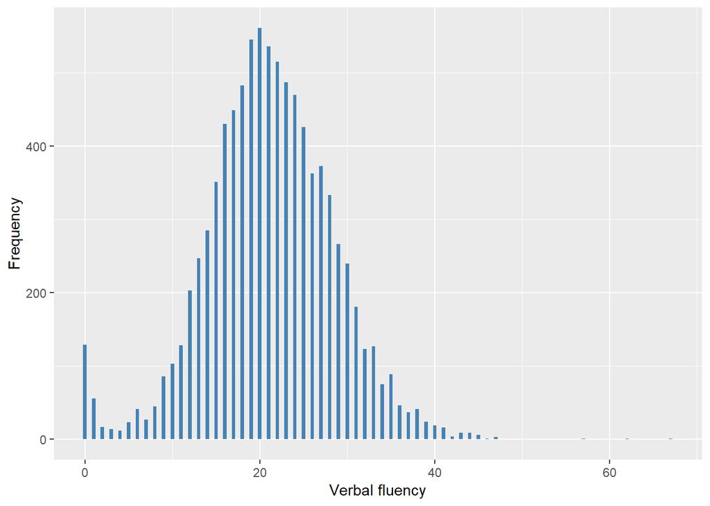

Cognition - verbal fluency. Test that assesses verbal (semantic) fluency: name as many animals as they could think of in 1 minute. Discrete variable: value 0 = <=25%; value 1 = >25%

| Sample size | Missing values |
| --- | --- |
| 9666 | 609 |

Category

|  | 0 | 1 |
| --- | --- | --- |
| Frequency | 2646.00 | 6411.00 |
| Percentage | 27.37 | 66.33 |

Type of missing

|  | 991 | 992 | 993 | 994 | 995 | 996 | 997 | 998 | 999 | NA |
| --- | --- | --- | --- | --- | --- | --- | --- | --- | --- | --- |
| Frequency | 0 | 0 | 0 | 0 | 0 | 597.00 | 12.00 | 0 | 0 | 0 |
| Percentage | 0 | 0 | 0 | 0 | 0 | 6.18 | 0.12 | 0 | 0 | 0 |

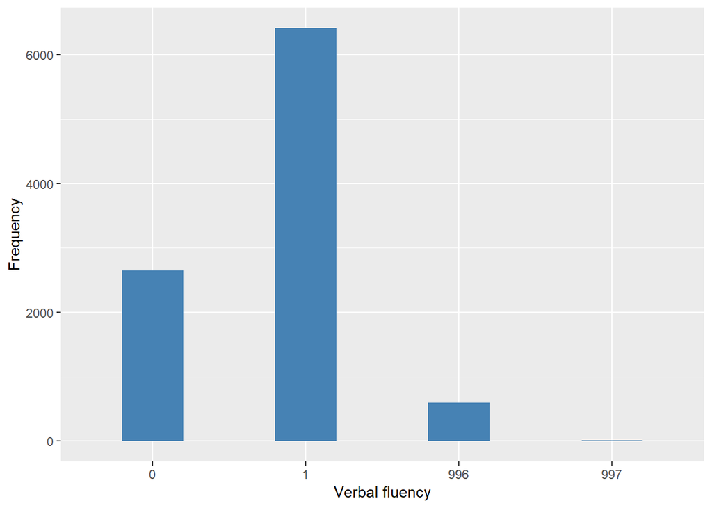

#### 2.1.7.4 Validation

Continuous vs Dichotomous

|  | 0:17->0 | 18:160->1 | -1->996 | -9->997 |
| --- | --- | --- | --- | --- |
| continuous | 2646 | 6411 | 597 | 12 |
| dichotomous | 2646 | 6411 | 597 | 12 |

## 2.2 Descriptive statistics of the harmonised variable `cog_verb` accross populations and waves

Two tables are generated:

1. Percentages of categories in each harmonised variable.
2. Frequencies and percentages of individuals with different trajectories. To avoid too large table, only trajectories with percentages larger than 0.3 are shown.

Cognition - verbal fluency. Test that assesses verbal (semantic) fluency: name as many animals as they could think of in 1 minute. Discrete variable: value 0 = <=25%; value 1 = >25%

| val | label | W1 | W2 | W3 | W4 | W5 | W7 |
| --- | --- | --- | --- | --- | --- | --- | --- |
| 0 | <=25% | 26.08 | 24.59 | 27.58 | 24.77 | 24.12 | 27.37 |
| 1 | >25% | 70.73 | 73.51 | 69.44 | 70.62 | 69.92 | 66.33 |
| 991 | CAPI interviewer error | 0 | 0 | 0 | 0 | 0 | 0 |
| 992 | Impute | 0 | 0 | 0 | 0 | 0 | 0 |
| 993 | Disable to measure | 0 | 0 | 0 | 0 | 0 | 0 |
| 994 | Not attempt not done | 0 | 0 | 0 | 0 | 0 | 0 |
| 995 | Does not answer | 0 | 0 | 0 | 0 | 0 | 0 |
| 996 | Not applicable | 2.41 | 1.61 | 2.76 | 4.04 | 5.23 | 6.18 |
| 997 | Refuse | 0.64 | 0.15 | 0.21 | 0.53 | 0.69 | 0.12 |
| 998 | Do not know | 0.14 | 0.15 | 0 | 0.04 | 0.04 | 0 |
| 999 | Missing | 0 | 0 | 0 | 0 | 0 | 0 |
| NA | NA | 0 | 0 | 0 | 0 | 0 | 0 |
| n | sample size | 12099 | 9432 | 9771 | 11050 | 10274 | 9666 |

|  | val | frq | raw.prc |
| --- | --- | --- | --- |
| 1 | 000000 | 153 | 0.84 |
| 3 | 00000NA | 114 | 0.63 |
| 8 | 0000NANA | 116 | 0.64 |
| 23 | 000NANANA | 229 | 1.26 |
| 60 | 00NANANANA | 292 | 1.60 |
| 95 | 011111 | 80 | 0.44 |
| 124 | 01NANANANA | 112 | 0.61 |
| 169 | 0NANANANANA | 886 | 4.86 |
| 170 | 100000 | 77 | 0.42 |
| 191 | 100NANANA | 84 | 0.46 |
| 204 | 101111 | 74 | 0.41 |
| 231 | 10NANANANA | 203 | 1.11 |
| 232 | 110000 | 57 | 0.31 |
| 244 | 110110 | 64 | 0.35 |
| 245 | 110111 | 120 | 0.66 |
| 258 | 110NANANA | 125 | 0.69 |
| 259 | 111000 | 58 | 0.32 |
| 263 | 111011 | 100 | 0.55 |
| 268 | 111100 | 91 | 0.50 |
| 269 | 111101 | 114 | 0.63 |
| 270 | 11110NA | 81 | 0.44 |
| 271 | 111110 | 323 | 1.77 |
| 272 | 111111 | 2061 | 11.31 |
| 273 | 11111NA | 398 | 2.18 |
| 276 | 1111NANA | 219 | 1.20 |
| 280 | 111NA11 | 57 | 0.31 |
| 284 | 111NANANA | 416 | 2.28 |
| 309 | 11NANANANA | 707 | 3.88 |
| 370 | 1NANANANANA | 1182 | 6.49 |
| 451 | NANA0NANANA | 79 | 0.43 |
| 464 | NANA1111 | 549 | 3.01 |
| 465 | NANA111NA | 147 | 0.81 |
| 468 | NANA11NANA | 87 | 0.48 |
| 477 | NANA1NANANA | 265 | 1.45 |
| 478 | NANANA000 | 136 | 0.75 |
| 480 | NANANA00NA | 81 | 0.44 |
| 481 | NANANA010 | 72 | 0.40 |
| 482 | NANANA011 | 86 | 0.47 |
| 486 | NANANA0NANA | 122 | 0.67 |
| 487 | NANANA100 | 69 | 0.38 |
| 488 | NANANA101 | 91 | 0.50 |
| 490 | NANANA110 | 169 | 0.93 |
| 491 | NANANA111 | 971 | 5.33 |
| 492 | NANANA11NA | 273 | 1.50 |
| 495 | NANANA1NANA | 279 | 1.53 |
| 500 | NANANANA11 | 54 | 0.30 |
| 502 | NANANANANA0 | 269 | 1.48 |
| 503 | NANANANANA1 | 1082 | 5.94 |
| 504 | NANANANANANA | 592 | 3.25 |

## 2.3 Summary of descriptive statistics of the harmonised variable `cog_verb_c` accross populations and waves

Cognition - verbal fluency. Test that assesses verbal (semantic) fluency: name as many animals as they could think of in 1 minute

| cog_verb_c | W1 | W2 | W3 | W4 | W5 | W7 |
| --- | --- | --- | --- | --- | --- | --- |
| Min. | 0 | 0 | 0 | 0 | 0 | 0 |
| 1st Qu. | 15 | 15 | 16 | 16 | 16 | 17 |
| Median | 19 | 20 | 20 | 21 | 21 | 21 |
| Mean | 19.33 | 19.81 | 20.24 | 20.71 | 20.79 | 21.13 |
| 3rd Qu. | 23 | 24 | 25 | 25 | 25 | 26 |
| Max. | 50 | 63 | 56 | 55 | 51 | 67 |
| No-missings | 11713 | 9252 | 9480 | 10541 | 9662 | 9057 |
| 991 | 0 | 0 | 0 | 0 | 0 | 0 |
| 992 | 0 | 0 | 0 | 0 | 0 | 0 |
| 993 | 0 | 0 | 0 | 0 | 0 | 0 |
| 994 | 0 | 0 | 0 | 0 | 0 | 0 |
| 995 | 0 | 0 | 0 | 0 | 0 | 0 |
| 996 | 292 | 152 | 270 | 446 | 537 | 597 |
| 997 | 77 | 14 | 21 | 59 | 71 | 12 |
| 998 | 17 | 14 | 0 | 4 | 4 | 0 |
| 999 | 0 | 0 | 0 | 0 | 0 | 0 |
| NA | 0 | 0 | 0 | 0 | 0 | 0 |
| sample size | 12099 | 9432 | 9771 | 11050 | 10274 | 9666 |

# 3 Quality estimation

No comments